# Antibiotic coverage comparisons for Pseudomonas aeruginosa

Compare five frequently tested drugs in Basel respiratory samples, using added coverage, conditional rescue, and total coverage. The analysis retains the same data preparation as Main_Analysis.Rmd.

## Data and testing frequency

```r
library(dplyr)
```

```r
library(ggplot2)
knitr::opts_chunk$set(echo = TRUE, message = FALSE, fig.width = 8,
                      fig.height = 4.5, dpi = 200,
                      fig.path = "outputs/figures/comparison_")
theme_set(theme_classic())
source("scripts/prepare_data.R")
prepared <- prepare_data()
wide <- prepared$order_data
frequency <- prepared$frequency
top_five <- head(frequency$drug, 5)
knitr::kable(head(frequency, 5))
```

| drug | Orders |
| --- | --- |
| Colistin | 637 |
| Tobramycin | 634 |
| Meropenem | 630 |
| Piperacillin-tazobactam | 623 |
| Ciprofloxacin | 618 |

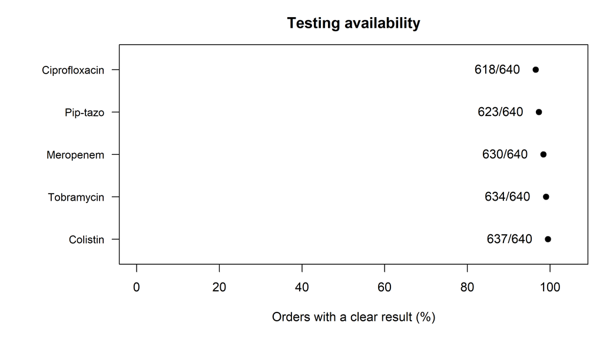

```r
availability <- data.frame(
  Drug = top_five,
  Orders = sapply(top_five, function(drug) sum(!is.na(wide[[drug]]))),
  Total_orders = nrow(wide))
availability$Percent <- 100 * availability$Orders / availability$Total_orders
availability$Label <- ifelse(availability$Drug == "Piperacillin-tazobactam",
                             "Pip-tazo", availability$Drug)

par(mar = c(5, 8, 3, 1))
plot(availability$Percent, seq_len(5), xlim = c(0, 105), ylim = c(0.6, 5.4), yaxt = "n", pch = 19,
     xlab = "Orders with a clear result (%)", ylab = "",
     main = "Testing availability")
axis(2, at = seq_len(5), labels = availability$Label, las = 1, cex.axis = 0.85)
text(availability$Percent - 2, seq_len(5),
     labels = paste0(availability$Orders, "/", availability$Total_orders), pos = 2)
```

The five drugs were selected by testing frequency. Missing results differ by drug, so pair comparisons below use a shared complete-case cohort.

## Common comparison sample

```r
complete_orders <- wide[complete.cases(wide[, top_five]), ]
samples <- first_eligible(wide, top_five)
knitr::kable(data.frame(
  Stage = c("Respiratory orders", "All five results available", "First eligible order per patient-year"),
  N = c(nrow(wide), nrow(complete_orders), nrow(samples))))
```

| Stage | N |
| --- | --- |
| Respiratory orders | 640 |
| All five results available | 598 |
| First eligible order per patient-year | 349 |

```r
single <- data.frame(
  Drug = top_five,
  Susceptible = sapply(top_five, function(drug) sum(samples[[drug]] == 0)),
  N = nrow(samples))
single$Coverage_percent <- 100 * single$Susceptible / single$N
knitr::kable(single, digits = 1, row.names = FALSE)
```

| Drug | Susceptible | N | Coverage_percent |
| --- | --- | --- | --- |
| Colistin | 346 | 349 | 99.1 |
| Tobramycin | 328 | 349 | 94.0 |
| Meropenem | 308 | 349 | 88.3 |
| Piperacillin-tazobactam | 292 | 349 | 83.7 |
| Ciprofloxacin | 287 | 349 | 82.2 |

All comparisons use 349 patient-year observations. Requiring all five results can select a later first eligible order than the two-drug analysis, so this is not simply the 350-sample cohort with one observation removed.

## Pair summaries

For each ordered pair: N = all samples, M = first-drug NS, Y = first-drug NS and second-drug S. Conditional rescue is Y/M, added coverage is Y/N, and total coverage is (N-M+Y)/N.

```r
pair_summary <- function(data, first, second) {
  N <- nrow(data)
  M <- sum(data[[first]] == 1)
  Y <- sum(data[[first]] == 1 & data[[second]] == 0)
  data.frame(First = first, Second = second, N = N, Missed = M, Rescued = Y,
             First_percent = 100 * (N - M) / N,
             Conditional_percent = if (M > 0) 100 * Y / M else NA_real_,
             Added_points = 100 * Y / N,
             Combined_percent = 100 * (N - M + Y) / N)
}
pairs <- expand.grid(First = top_five, Second = top_five, stringsAsFactors = FALSE)
pairs <- pairs[pairs$First != pairs$Second, ]
comparison <- bind_rows(lapply(seq_len(nrow(pairs)), function(i) {
  pair_summary(samples, pairs$First[i], pairs$Second[i])
}))
```

## Combinations from different drug families

Pip-tazo and meropenem are the beta-lactam starting drugs; the additions are colistin (polymyxin), tobramycin (aminoglycoside), and cipro (fluoroquinolone). This filter groups the two beta-lactam subgroups in EDA Table 4 together.

```r
first_drugs <- c("Piperacillin-tazobactam", "Meropenem")
second_drugs <- top_five[!top_five %in% first_drugs]
class_pairs <- comparison |>
  filter(First %in% first_drugs, Second %in% second_drugs)
knitr::kable(class_pairs |> select(First, Second, N, Missed, Rescued,
                                  Conditional_percent, Added_points, Combined_percent), digits = 1)
```

| First | Second | N | Missed | Rescued | Conditional_percent | Added_points | Combined_percent |
| --- | --- | --- | --- | --- | --- | --- | --- |
| Meropenem | Colistin | 349 | 41 | 41 | 100.0 | 11.7 | 100.0 |
| Piperacillin-tazobactam | Colistin | 349 | 57 | 55 | 96.5 | 15.8 | 99.4 |
| Meropenem | Tobramycin | 349 | 41 | 32 | 78.0 | 9.2 | 97.4 |
| Piperacillin-tazobactam | Tobramycin | 349 | 57 | 46 | 80.7 | 13.2 | 96.8 |
| Meropenem | Ciprofloxacin | 349 | 41 | 21 | 51.2 | 6.0 | 94.3 |
| Piperacillin-tazobactam | Ciprofloxacin | 349 | 57 | 35 | 61.4 | 10.0 | 93.7 |

```r
plot_data <- class_pairs
plot_data$First <- factor(ifelse(plot_data$First == "Piperacillin-tazobactam",
                                  "Pip-tazo", plot_data$First),
                           levels = c("Meropenem", "Pip-tazo"))
plot_data$Second <- factor(plot_data$Second, levels = second_drugs)
```

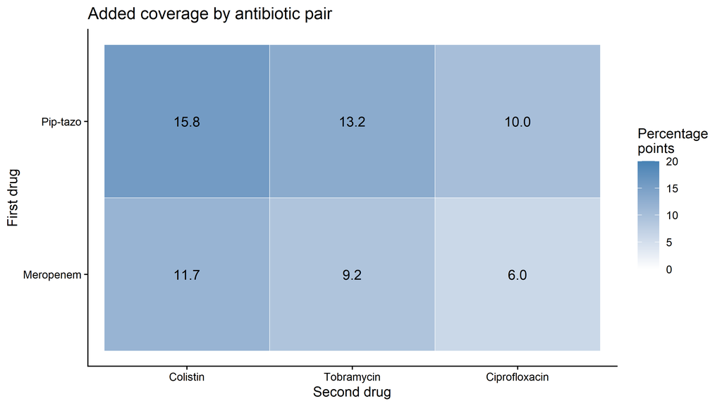

```r
added_plot <- ggplot(plot_data, aes(Second, First, fill = Added_points)) +
  geom_tile(color = "white") +
  geom_text(aes(label = sprintf("%.1f", Added_points))) +
  scale_fill_gradient(low = "white", high = "steelblue", limits = c(0, 20)) +
  labs(title = "Added coverage by antibiotic pair", x = "Second drug", y = "First drug",
       fill = "Percentage\npoints") +
  theme_classic()
added_plot
```

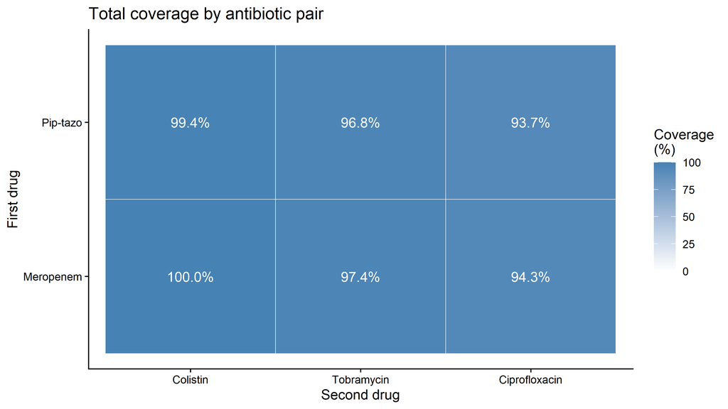

```r
total_plot <- ggplot(plot_data, aes(Second, First, fill = Combined_percent)) +
  geom_tile(color = "white") +
  geom_text(aes(label = sprintf("%.1f%%", Combined_percent)), color = "white") +
  scale_fill_gradient(low = "white", high = "steelblue", limits = c(0, 100)) +
  labs(title = "Total coverage by antibiotic pair", x = "Second drug", y = "First drug",
       fill = "Coverage\n(%)") +
  theme_classic()
total_plot
```

Colistin adds the most observed coverage after either starting drug in this sample. These are historical susceptibility estimates; the comparison does not assess prescribing suitability, treatment effects, or clinical outcomes.

## Pairwise availability sensitivity check

```r
pairwise <- bind_rows(lapply(seq_len(nrow(class_pairs)), function(i) {
  first <- class_pairs$First[i]
  second <- class_pairs$Second[i]
  pair_summary(first_eligible(wide, c(first, second)), first, second)
}))
sensitivity <- merge(class_pairs[, c("First", "Second", "N", "Added_points")],
                     pairwise[, c("First", "Second", "N", "Added_points")],
                     by = c("First", "Second"), suffixes = c("_common", "_pairwise"))
sensitivity$Change_points <- sensitivity$Added_points_pairwise - sensitivity$Added_points_common
knitr::kable(sensitivity, digits = 2)
```

| First | Second | N_common | Added_points_common | N_pairwise | Added_points_pairwise | Change_points |
| --- | --- | --- | --- | --- | --- | --- |
| Meropenem | Ciprofloxacin | 349 | 6.02 | 352 | 5.97 | -0.05 |
| Meropenem | Colistin | 349 | 11.75 | 355 | 11.55 | -0.20 |
| Meropenem | Tobramycin | 349 | 9.17 | 355 | 9.30 | 0.13 |
| Piperacillin-tazobactam | Ciprofloxacin | 349 | 10.03 | 350 | 9.71 | -0.31 |
| Piperacillin-tazobactam | Colistin | 349 | 15.76 | 353 | 15.58 | -0.18 |
| Piperacillin-tazobactam | Tobramycin | 349 | 13.18 | 353 | 13.03 | -0.15 |

## Limitations

Complete testing may select a different population, and patient labels cannot be linked across years. Sample rankings and 100% observed coverage do not establish population rankings or guaranteed coverage in future samples.